```r
library(tidyverse)
```

## Introducción

En esta tarea encontrarás la respuesta al primer ejercicio de la tarea 9, y la continuación con preguntas de bootstrap paramétrico

*Entrega:* martes 31 octubre por correo (usual)

### Ejercicio 1:

crear funcion de verosim con el ejemplo de numéro de errores

```r
crear_log_verosim <- function(n, n_err){
  # n es tamaño de muestra
  # n_err el número de errores detectados (datos)
  n_corr <- n - n_err
  log_verosim <- function(p){
    n_err * log(p) + n_corr * log(1-p)
  }
}
```

*Pregunta:* ¿qué devuelve esta función? *R:* devuelve una función de un parámetro

Utiliza esta función para construir la función de log verosimilitud cuando los datos observados son n = 500, y le número de errores observados es 121

```r
log_v <- crear_log_verosim(n = 500, n_err = 121)
```

Usa max verosimilitud para estimar el porcentaje de errores en la tabla de datos de donde se sacó la muestra usa la función optimize

```r
optim <- optimize(log_v, interval = c(0, 1), maximum = TRUE)
optim
```

```
## $maximum
## [1] 0.2420091
##
## $objective
## [1] -276.6872
```

### Grafica la funcion de verosimilitud para p entre cero y uno.

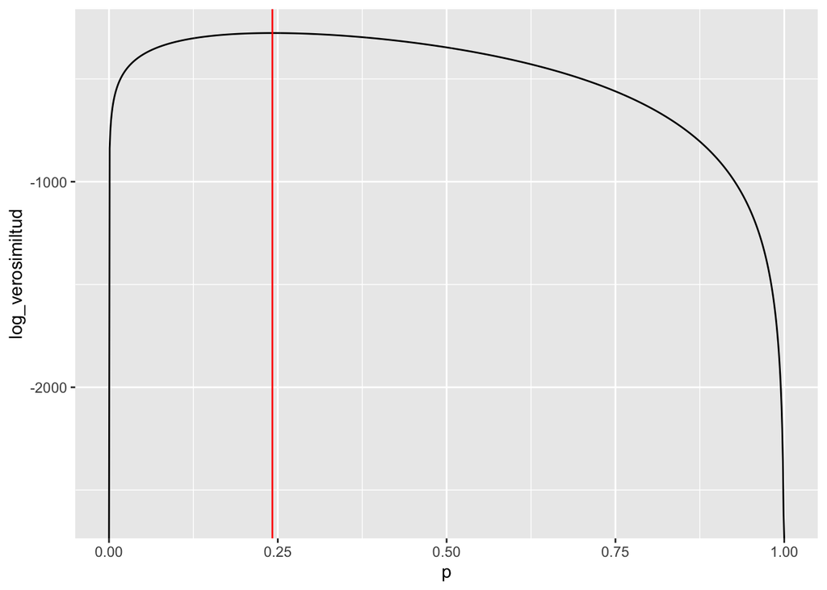

```r
grafica_tbl <- tibble(p = seq(0, 1, 0.001)) %>%
  mutate(log_verosimiltud = map_dbl(p, log_v))
ggplot(grafica_tbl, aes(x = p, y = log_verosimiltud)) +
  geom_line() +
  geom_vline(xintercept = optim$maximum, color = "red")
```

### Repite el ejercicio anterior si observas 317 errores

```r
log_v <- crear_log_verosim(n = 500, n_err = 317)

optim <- optimize(log_v, interval = c(0, 1), maximum = TRUE)
optim
```

```
## $maximum
## [1] 0.6340049
##
## $objective
## [1] -328.3962
```

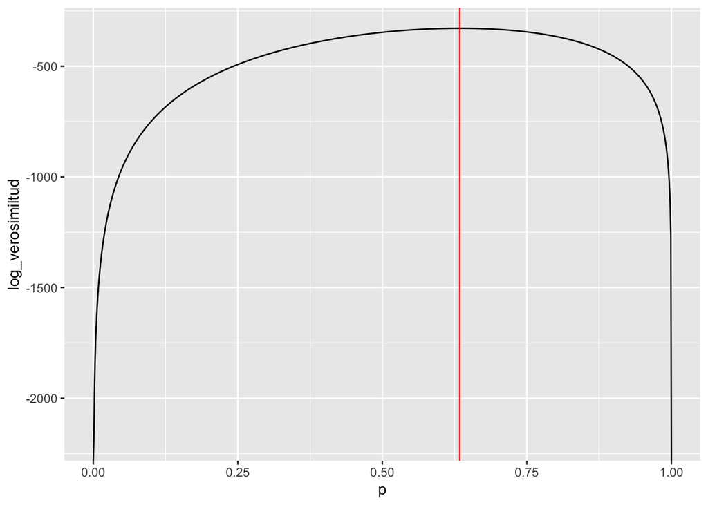

```r
grafica_tbl <- tibble(p = seq(0, 1, 0.001)) %>%
  mutate(log_verosimiltud = map_dbl(p, log_v))
ggplot(grafica_tbl, aes(x = p, y = log_verosimiltud)) +
  geom_line() +
  geom_vline(xintercept = optim$maximum, color = "red")
```